# YAPR

Yards Above Prediced Return Using Player Tracking Data

Nicholas Kondo, Tino Diaz-Ordaz, Max Batsch

## Exploring and Cleaning our Data

**Loading the Data**

```r
PFFScoutingData <- read_csv("/Users/nickkondo/OneDrive - Chapman University/R/NFL/Datasets/PFFScoutingData.csv")
players <- read_csv("/Users/nickkondo/OneDrive - Chapman University/R/NFL/Datasets/players.csv")
games <- read_csv("/Users/nickkondo/OneDrive - Chapman University/R/NFL/Datasets/games.csv")
plays <- read_csv("/Users/nickkondo/OneDrive - Chapman University/R/NFL/Datasets/plays.csv")
tracking2018 <- read_csv("/Users/nickkondo/OneDrive - Chapman University/R/NFL/Datasets/tracking2018.csv")
tracking2019 <- read_csv("/Users/nickkondo/OneDrive - Chapman University/R/NFL/Datasets/tracking2019.csv")
tracking2020 <- read_csv("/Users/nickkondo/OneDrive - Chapman University/R/NFL/Datasets/tracking2020.csv")
```

**Checking NA Values**

Let’s take a look into our data and see how many NA values there are in our data set across variables.

```r
sort(colSums(is.na(tracking2018)))
```

```
##          time             x             y             s             a
##             0             0             0             0             0
##           dis         event   displayName          team       frameId
##             0             0             0             0             0
##        gameId        playId playDirection             o           dir
##             0             0             0        555537        555537
##         nflId  jerseyNumber      position
##        555537        555537        555537
```

**Finding the Display Name for with NA Values**

We have 555,537 NA values under a few variables including nflId, jersey number, and position. nflID is a unique ID for every player in the NFL. This means that we have a handful of observations where there is no player. What is accounting for these NA values?

```r
table(tracking2018[is.na(tracking2018$nflId), "displayName"])
```

```
##
## football
##   555537
```

## Filtering Our Data Set

There are 555,537 observations where the football is being tracked rather than a player. To clean up our data set so we only have observations of the players being tracked, let’s remove the observations with ‘football’ as the display name. We will also use filter so that we are returning only the frames of the ‘kickoff’ and ‘kick_received’. Now let’s see how many NA values we have.

**2018**

```r
kick18 <- tracking2018 %>%
    # Filtering so the football is removed
filter(displayName != "football")

# Filtering so we only see the frames kick received
kick18 <- kick18 %>%
    filter(event == "kick_received")
```

**2019**

```r
kick19 <- tracking2019 %>%
    # Filtering so the football is removed
filter(displayName != "football")

# Filtering so we only see the frames of kick received
kick19 <- kick19 %>%
    filter(event == "kick_received")
```

**2020**

```r
kick20 <- tracking2020 %>%
    # Filtering so the football is removed
filter(displayName != "football")

# Filtering so we only see the frames of kick received
kick20 <- kick20 %>%
    filter(event == "kick_received")
```

```r
kick <- rbind(kick18, kick19, kick20)

sort(colSums(is.na(kick)))
```

```
##          time             x             y             s             a
##             0             0             0             0             0
##           dis             o           dir         event         nflId
##             0             0             0             0             0
##   displayName  jerseyNumber      position          team       frameId
##             0             0             0             0             0
##        gameId        playId playDirection
##             0             0             0
```

## Joining Tables

**Joining the Tracking, Plays, and PFF Scouting Tables**

The `plays` table and `PFFScouting` table are joined and the filter function is used to return kickoff plays only. Onside, squib kicks, and punts are removed and stored in an object `kickoffs`.

```r
# Combining our plays data with our tracking(kick) data
kick_plays <- inner_join(x = kick, y = plays, by = c("gameId", "playId"))

# Combining our tracking and plays data with our PFF Scouting Data
kick_plays_PFF <- inner_join(x = kick_plays, y = PFFScoutingData, by = c("gameId",
    "playId"))

# Filtering out only the kickoff play type
kickoffs <- kick_plays_PFF %>%
    filter(specialTeamsPlayType == "Kickoff") %>%
    # We are going to keep deep, flat, and pooch kicks
filter(kickType == "D" | kickType == "F" | kickType == "P")

# Changing the character variables to factors
kickoffs <- as.data.frame(unclass(kickoffs), stringsAsFactors = TRUE)

head(kickoffs)
```

|  | time | x | y | s | a | dis | o | dir | event | nflId | displayName | jerseyNumber | position | team | frameId | gameId | playId | playDirection | playDescription | quarter | down | yardsToGo | possessionTeam | specialTeamsPlayType | specialTeamsResult | kickerId | returnerId | kickBlockerId | yardlineSide | … |
| --- | --- | --- | --- | --- | --- | --- | --- | --- | --- | --- | --- | --- | --- | --- | --- | --- | --- | --- | --- | --- | --- | --- | --- | --- | --- | --- | --- | --- | --- | --- |
| 1 | 2018-12-30 21:25:37 | 64.55 | 26.23 | 6.29 | 0.59 | 0.63 | 88.91 | 90.88 | kick_received | 39470 | Justin Tucker | 9 | K | home | 53 | 2018123000 | 36 | right | J.Tucker kicks 60 yards from BAL 35 to CLE 5. J.Peppers to CLE 34 for 29 yards (C.Moore; K.Young). | 1 | 0 | 0 | BAL | Kickoff | Return | 39470 | 44837 | NA | BAL | … |
| 2 | 2018-12-30 21:25:37 | 80.81 | 20.81 | 2.83 | 3.85 | 0.29 | 312.97 | 21.85 | kick_received | 40579 | Ray-Ray Armstrong | 52 | OLB | away | 53 | 2018123000 | 36 | right | J.Tucker kicks 60 yards from BAL 35 to CLE 5. J.Peppers to CLE 34 for 29 yards (C.Moore; K.Young). | 1 | 0 | 0 | BAL | Kickoff | Return | 39470 | 44837 | NA | BAL | … |
| 3 | 2018-12-30 21:25:37 | 84.82 | 13.04 | 4.36 | 2.66 | 0.45 | 309.48 | 52.99 | kick_received | 41316 | Phillip Gaines | 33 | CB | away | 53 | 2018123000 | 36 | right | J.Tucker kicks 60 yards from BAL 35 to CLE 5. J.Peppers to CLE 34 for 29 yards (C.Moore; K.Young). | 1 | 0 | 0 | BAL | Kickoff | Return | 39470 | 44837 | NA | BAL | … |
| 4 | 2018-12-30 21:25:37 | 77.37 | 35.51 | 9.00 | 2.51 | 0.91 | 105.69 | 108.92 | kick_received | 42398 | Maxx Williams | 87 | TE | home | 53 | 2018123000 | 36 | right | J.Tucker kicks 60 yards from BAL 35 to CLE 5. J.Peppers to CLE 34 for 29 yards (C.Moore; K.Young). | 1 | 0 | 0 | BAL | Kickoff | Return | 39470 | 44837 | NA | BAL | … |
| 5 | 2018-12-30 21:25:37 | 79.07 | 40.84 | 9.36 | 2.45 | 0.95 | 102.08 | 98.79 | kick_received | 42437 | Ty Montgomery | 88 | RB | home | 53 | 2018123000 | 36 | right | J.Tucker kicks 60 yards from BAL 35 to CLE 5. J.Peppers to CLE 34 for 29 yards (C.Moore; K.Young). | 1 | 0 | 0 | BAL | Kickoff | Return | 39470 | 44837 | NA | BAL | … |
| 6 | 2018-12-30 21:25:37 | 80.48 | 22.66 | 2.43 | 2.52 | 0.25 | 263.32 | 82.64 | kick_received | 42608 | Jermaine Whitehead | 35 | FS | away | 53 | 2018123000 | 36 | right | J.Tucker kicks 60 yards from BAL 35 to CLE 5. J.Peppers to CLE 34 for 29 yards (C.Moore; K.Young). | 1 | 0 | 0 | BAL | Kickoff | Return | 39470 | 44837 | NA | BAL | … |

### Summary Statistics

**Number of Unique Plays and Games**

How many unique plays and games do we have in our data set now?

```r
length(unique(kickoffs$playId))
```

```
## [1] 2115
```

```r
length(unique(kickoffs$gameId))
```

```
## [1] 724
```

**X and Y Dimensions**

What are the dimensions of our X and Y coordinates?

```r
min(kickoffs$x)
```

```
## [1] 0.76
```

```r
max(kickoffs$x)
```

```
## [1] 119.52
```

```r
min(kickoffs$y)
```

```
## [1] -2
```

```r
max(kickoffs$y)
```

```
## [1] 61.99
```

## Feature Engineering

**New Features**

Here we are creating new features and explanation behind why these features were created:

`yard_result`: The yard line the play results in, or the yard line the returner carried the ball to before being tackled. The yard result is going to be the value that we are aiming to predict.

`YardResult_Over25`: A binary indicator if the yard resulted in the 25 yard line or more. The 25 yard line is where the ball is placed if the play result in a touchback.

> We want to make this more actionable and into a simple yes or no decision. On kickoffs, the returner has the decision to catch the ball and return the kick, or the decision to let the ball land in the end zone and result in a touchback.

> A touchback results in the ball being placed at the 25 yard line. If the returner expects to run the ball beyond the 25 yard line, he should make the decision to return it. If the returner does not think he can run the ball past the 25 yard line, he should let the ball land in the end zone to receive a touchback (ball placed at 25 yard line). Some things that influence what yard the returner gets to are how far the kick is (or where the returner catches the ball), the hang time of the kick, how fast the returner is, how far the defenders are, and much more. To start, let’s create a new feature, a binary variable ’did the returner reach beyond the 25 yard line or not.

> When a returner sets up to catch a ball, the returner has the decision to take the ball out of the end zone and gain yards, or if the ball lands in the end zone it’s ruled as a touchback and the ball is placed at the 25 yard line. For this reason we will consider returns further than the 25 yard line as a success and returns less than the 25 yard line as a failure.

`kickto_yardline` - The yard line the ball was kicked to, or the yard line the player caught(or dropped) the ball.

`Y_position` - The position the field a player is. We categorize this into 4 locations: left = left of the hash right = right of the hash center = in between the hashes out of bounds = not in the boundaries of the field

> The exact yard line a returner catches the ball may not be a great predictor of yard line result because if we separate the yard line by each yard, there are too few observations at each level. A new feature that we will create and test is 5-yard bins. This is more actionable because when a player is looking at the sky catching a ball, he may not know what exact yard line he’s standing on, but he will have a good idea of what 5 yard bin he’s standing in.

```r
kickoffs <- kickoffs %>%
         # Creating a variable for what yard line the play resulted at
  mutate(yard_result = (100 - yardlineNumber) - playResult,

         # Creating a binary variable for if the ball reached the 25 yard line or not
         YardResult_over25 = ifelse(yard_result > 25 | yard_result == 25,'1','0'),

         # Creating a variable for which yard line the ball was kicked to
         kickedto_yardline = 100 - (yardlineNumber + kickLength),

         # Creating a variable for Y position on the field
         Y_position = ifelse(y < 23.36667 & y > 0, 'left',
                      ifelse(y > 29.96667 & y < 53.3333, 'right',
                      ifelse(y > 23.36667 & y < 53.3333, 'center',
                      ifelse(y < 0 | y > 53.3333, "out of bounds", 'NA')))),

         # Creating a variable for 5-yard bins
         kickedto_5yardBin =
           ifelse(kickedto_yardline >= -10 & -5 > kickedto_yardline, "back-half endzone",
           ifelse(kickedto_yardline >= -5 & 0 > kickedto_yardline, "front-half endzone",
           ifelse(kickedto_yardline >= 0 & 5 > kickedto_yardline, "0-5",
           ifelse(kickedto_yardline >= 5 & 10 > kickedto_yardline, "5-10",
           ifelse(kickedto_yardline >= 10 & 15 > kickedto_yardline, "10-15",
           ifelse(kickedto_yardline >= 15 & 20 > kickedto_yardline, "15-20",
           ifelse(kickedto_yardline >= 20 & 25 > kickedto_yardline, "20-25",
           ifelse(kickedto_yardline >= 25 & 30 > kickedto_yardline, "25-30",
           ifelse(kickedto_yardline >= 30 & 35 > kickedto_yardline, "30-35",
           ifelse(kickedto_yardline >= 35 & 40 > kickedto_yardline, "35-40",
           ifelse(kickedto_yardline >= 40 & 45 > kickedto_yardline, "40-45",
           ifelse(kickedto_yardline >= 45 & 50 > kickedto_yardline, "45-50",
           ifelse(kickedto_yardline >= 50 & 55 > kickedto_yardline, "50-55",
           ifelse(kickedto_yardline >= 55 & 60 > kickedto_yardline, "55-60",
           ifelse(kickedto_yardline >= 60 & 65 > kickedto_yardline, "60-65","NA")
           )))))))))))))))

# Changing variables to factors
kickoffs <- as.data.frame(unclass(kickoffs),
                                  stringsAsFactors = TRUE)

head(kickoffs)
```

|  | time | x | y | s | a | dis | o | dir | event | nflId | displayName | jerseyNumber | position | team | frameId | gameId | playId | playDirection | playDescription | quarter | down | yardsToGo | possessionTeam | specialTeamsPlayType | specialTeamsResult | kickerId | returnerId | kickBlockerId | yardlineSide | … |
| --- | --- | --- | --- | --- | --- | --- | --- | --- | --- | --- | --- | --- | --- | --- | --- | --- | --- | --- | --- | --- | --- | --- | --- | --- | --- | --- | --- | --- | --- | --- |
| 1 | 2018-12-30 21:25:37 | 64.55 | 26.23 | 6.29 | 0.59 | 0.63 | 88.91 | 90.88 | kick_received | 39470 | Justin Tucker | 9 | K | home | 53 | 2018123000 | 36 | right | J.Tucker kicks 60 yards from BAL 35 to CLE 5. J.Peppers to CLE 34 for 29 yards (C.Moore; K.Young). | 1 | 0 | 0 | BAL | Kickoff | Return | 39470 | 44837 | NA | BAL | … |
| 2 | 2018-12-30 21:25:37 | 80.81 | 20.81 | 2.83 | 3.85 | 0.29 | 312.97 | 21.85 | kick_received | 40579 | Ray-Ray Armstrong | 52 | OLB | away | 53 | 2018123000 | 36 | right | J.Tucker kicks 60 yards from BAL 35 to CLE 5. J.Peppers to CLE 34 for 29 yards (C.Moore; K.Young). | 1 | 0 | 0 | BAL | Kickoff | Return | 39470 | 44837 | NA | BAL | … |
| 3 | 2018-12-30 21:25:37 | 84.82 | 13.04 | 4.36 | 2.66 | 0.45 | 309.48 | 52.99 | kick_received | 41316 | Phillip Gaines | 33 | CB | away | 53 | 2018123000 | 36 | right | J.Tucker kicks 60 yards from BAL 35 to CLE 5. J.Peppers to CLE 34 for 29 yards (C.Moore; K.Young). | 1 | 0 | 0 | BAL | Kickoff | Return | 39470 | 44837 | NA | BAL | … |
| 4 | 2018-12-30 21:25:37 | 77.37 | 35.51 | 9.00 | 2.51 | 0.91 | 105.69 | 108.92 | kick_received | 42398 | Maxx Williams | 87 | TE | home | 53 | 2018123000 | 36 | right | J.Tucker kicks 60 yards from BAL 35 to CLE 5. J.Peppers to CLE 34 for 29 yards (C.Moore; K.Young). | 1 | 0 | 0 | BAL | Kickoff | Return | 39470 | 44837 | NA | BAL | … |
| 5 | 2018-12-30 21:25:37 | 79.07 | 40.84 | 9.36 | 2.45 | 0.95 | 102.08 | 98.79 | kick_received | 42437 | Ty Montgomery | 88 | RB | home | 53 | 2018123000 | 36 | right | J.Tucker kicks 60 yards from BAL 35 to CLE 5. J.Peppers to CLE 34 for 29 yards (C.Moore; K.Young). | 1 | 0 | 0 | BAL | Kickoff | Return | 39470 | 44837 | NA | BAL | … |
| 6 | 2018-12-30 21:25:37 | 80.48 | 22.66 | 2.43 | 2.52 | 0.25 | 263.32 | 82.64 | kick_received | 42608 | Jermaine Whitehead | 35 | FS | away | 53 | 2018123000 | 36 | right | J.Tucker kicks 60 yards from BAL 35 to CLE 5. J.Peppers to CLE 34 for 29 yards (C.Moore; K.Young). | 1 | 0 | 0 | BAL | Kickoff | Return | 39470 | 44837 | NA | BAL | … |

**Releveling Factor Variables**

Re leveling the `kickedto_5yardBin` so they are in proper order.

```r
# Releveling the 5-Yard bins
kickoffs <- kickoffs %>%
    mutate(kickedto_5yardBin = fct_relevel(kickedto_5yardBin, "back-half endzone",
        "front-half endzone", "0-5", "5-10", "10-15", "15-20", "20-25",
        "25-30", "30-35", "35-40", "40-45", "45-50", "50-55", "55-60"))

levels(kickoffs$kickedto_5yardBin)
```

```
##  [1] "back-half endzone"  "front-half endzone" "0-5"
##  [4] "5-10"               "10-15"              "15-20"
##  [7] "20-25"              "25-30"              "30-35"
## [10] "35-40"              "40-45"
```

**Creating a Table for Returns Only**

We only want to use the plays where the returner made the decision to return it. `Downed`, `Fair Catch`, `Out of Bounds`, and `Touchback` don’t have any outcome to evaluate. `Muffed` means the player did not catch it cleanly but the player still returned the ball so we will leave that variable in.

```r
table(kickoffs$specialTeamsResult)
```

```
##
##        Muffed Out of Bounds        Return     Touchback
##          1056            44         57574         14234
```

```r
returns <- kickoffs %>%
    filter(specialTeamsResult == "Return" | specialTeamsResult == "Muffed")

table(returns$specialTeamsResult)
```

```
##
##        Muffed Out of Bounds        Return     Touchback
##          1056             0         57574             0
```

### Summary Statistics

```r
summary(kickoffs$kickedto_yardline)
```

```
##     Min.  1st Qu.   Median     Mean  3rd Qu.     Max.
## -10.0000  -3.0000   0.0000   0.8582   4.0000  40.0000
```

```r
summary(returns$yard_result)
```

```
##    Min. 1st Qu.  Median    Mean 3rd Qu.    Max.
##    3.00   19.00   24.00   24.89   29.00  100.00
```

Here is the variable 5 yard bin kicked to compared to the yard result. We can see that where the ball is kicked is correlated in some way with the yard result. This aligns with our hypothesis that the further the ball is kicked, the smaller the yard line the player will likely end up. One thing to notice is when the ball is kicked in the back of the end zone, the highest yard line a returner ran to was the 50 yard line. (100 = score)

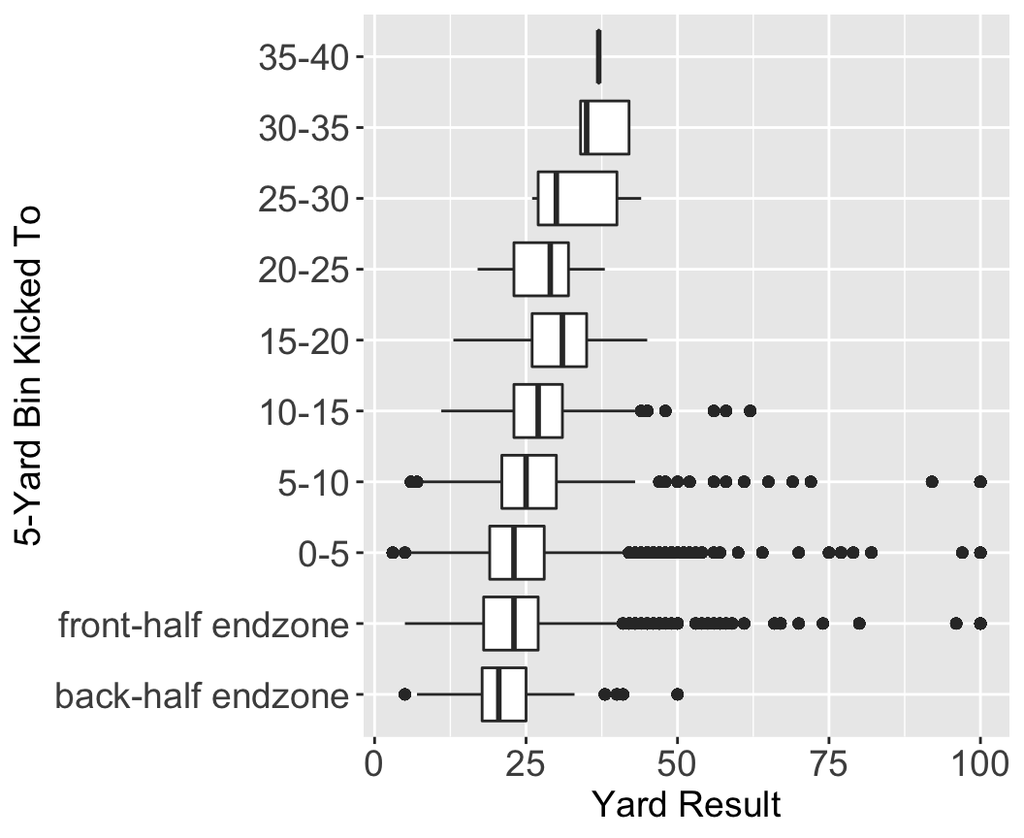

```r
ggplot(returns, aes(x = kickedto_5yardBin, y = yard_result)) + geom_boxplot() +
    coord_flip() + xlab("5-Yard Bin Kicked To") + ylab("Yard Result") +
    theme(axis.text = element_text(size = 14), axis.title = element_text(size = 14))
```

### Creating Defenders (Kickoff Team) and Defender Variables

The data set is expanded so that for every player or `displayName`, there are 11 observations, where 11 defenders and their location, distance, speed, acceleration, and more variables are included. We slice our data to return the 10 closest defenders because these are the players running down the field while the kicker usually lags behind.

```r
# Creating a new variable Opposing team because we eventually want to
# find the distance from the opposing players, not team players

# If a player is on the away team, lets return the home team, else,
# let's return away
returns$opp_team <- ifelse(returns$team == "away", "home", "away")

# Sanity check
table(returns$opp_team == returns$team)
```

```
##
## FALSE
## 58630
```

```r
# Creating a data set for the moment of the ball being caught
received <- returns %>%
    filter(event == "kick_received")

# Joining returns2 onto itself where team = opp_team and creating 11
# rows for each player with a defender added

receivedJoin <- left_join(received, received[, c("gameId", "playId", "nflId",
    "displayName", "opp_team", "x", "y", "s", "a", "dis")], by = c(gameId = "gameId",
    playId = "playId", team = "opp_team"))

# Creating a variable for distance from returner or 'ball carrier'
receivedJoin$distance <- (((receivedJoin$x.x - receivedJoin$x.y)^2) + (receivedJoin$y.x -
    receivedJoin$y.y)^2)^0.5

# Using filter to return the only the returner
receivedJoin <- receivedJoin %>%
    filter(receivedJoin$nflId.x == receivedJoin$returnerId)


# We are grabbing the 10 closest defenders because the kicker should
# be removed from the play when evaluating the kickoff team

# Average Yardline Average
received10 <- receivedJoin %>%
    group_by(displayName.x, gameId, playId) %>%
    slice_min(distance, n = 10) %>%
    # Creating average distance, speed, and acceleration variables
mutate(KoTeamAvgX = mean(x.x), KoTeamAvgDist = mean(distance), KoTeamAvgSpeed = mean(s.y),
    KoTeamAvgA = mean(a.y))

head(received10)
```

| time | x.x | y.x | s.x | a.x | dis.x | o | dir | event | nflId.x | displayName.x | jerseyNumber | position | team | frameId | gameId | playId | playDirection | playDescription | quarter | down | yardsToGo | possessionTeam | specialTeamsPlayType | specialTeamsResult | kickerId | returnerId | kickBlockerId | yardlineSide | yardlineNumber | … |
| --- | --- | --- | --- | --- | --- | --- | --- | --- | --- | --- | --- | --- | --- | --- | --- | --- | --- | --- | --- | --- | --- | --- | --- | --- | --- | --- | --- | --- | --- | --- |
| 2018-09-09 19:49:29 | 30.76 | 40.55 | 1.81 | 1.65 | 0.18 | 94.43 | 95.11 | kick_received | 43010 | Adam Humphries | 10 | WR | away | 50 | 2018090906 | 3901 | left | W.Lutz kicks 44 yards from NO 35 to TB 21. A.Humphries to TB 25 for 4 yards (J.Hardee). | 4 | 0 | 0 | NO | Kickoff | Return | 43689 | 43010 | NA | NO | 35 | … |
| 2018-09-09 19:49:29 | 30.76 | 40.55 | 1.81 | 1.65 | 0.18 | 94.43 | 95.11 | kick_received | 43010 | Adam Humphries | 10 | WR | away | 50 | 2018090906 | 3901 | left | W.Lutz kicks 44 yards from NO 35 to TB 21. A.Humphries to TB 25 for 4 yards (J.Hardee). | 4 | 0 | 0 | NO | Kickoff | Return | 43689 | 43010 | NA | NO | 35 | … |
| 2018-09-09 19:49:29 | 30.76 | 40.55 | 1.81 | 1.65 | 0.18 | 94.43 | 95.11 | kick_received | 43010 | Adam Humphries | 10 | WR | away | 50 | 2018090906 | 3901 | left | W.Lutz kicks 44 yards from NO 35 to TB 21. A.Humphries to TB 25 for 4 yards (J.Hardee). | 4 | 0 | 0 | NO | Kickoff | Return | 43689 | 43010 | NA | NO | 35 | … |
| 2018-09-09 19:49:29 | 30.76 | 40.55 | 1.81 | 1.65 | 0.18 | 94.43 | 95.11 | kick_received | 43010 | Adam Humphries | 10 | WR | away | 50 | 2018090906 | 3901 | left | W.Lutz kicks 44 yards from NO 35 to TB 21. A.Humphries to TB 25 for 4 yards (J.Hardee). | 4 | 0 | 0 | NO | Kickoff | Return | 43689 | 43010 | NA | NO | 35 | … |
| 2018-09-09 19:49:29 | 30.76 | 40.55 | 1.81 | 1.65 | 0.18 | 94.43 | 95.11 | kick_received | 43010 | Adam Humphries | 10 | WR | away | 50 | 2018090906 | 3901 | left | W.Lutz kicks 44 yards from NO 35 to TB 21. A.Humphries to TB 25 for 4 yards (J.Hardee). | 4 | 0 | 0 | NO | Kickoff | Return | 43689 | 43010 | NA | NO | 35 | … |
| 2018-09-09 19:49:29 | 30.76 | 40.55 | 1.81 | 1.65 | 0.18 | 94.43 | 95.11 | kick_received | 43010 | Adam Humphries | 10 | WR | away | 50 | 2018090906 | 3901 | left | W.Lutz kicks 44 yards from NO 35 to TB 21. A.Humphries to TB 25 for 4 yards (J.Hardee). | 4 | 0 | 0 | NO | Kickoff | Return | 43689 | 43010 | NA | NO | 35 | … |

**Selecting Relevant Variables**

Let’s roll this data back up and selecting only the variables that we want.

```r
clean <- received10 %>%
    select(time, x.x, y.x, event, displayName.x, nflId.x, returnerId, position,
        gameId, playId, frameId, playDescription, kickReturnYardage, yard_result,
        YardResult_over25, kickedto_yardline, kickedto_5yardBin, Y_position,
        KoTeamAvgX, KoTeamAvgDist, KoTeamAvgSpeed, KoTeamAvgA, specialTeamsPlayType,
        specialTeamsResult, kickType, hangTime, kickDirectionIntended,
        kickDirectionActual, returnDirectionIntended, returnDirectionActual,
        kickoffReturnFormation)

df <- unique(clean)
```

## Visualizations

### Histograms

**Frequency of 5-Yard Bins the Ball is Kicked To**

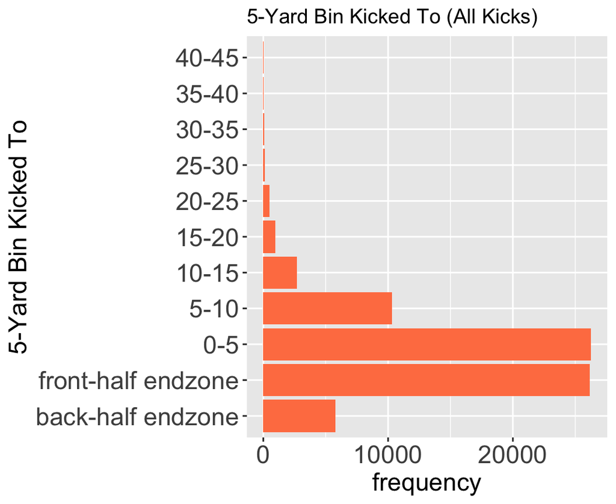

```r
ggplot(kickoffs, aes(x = kickedto_5yardBin)) + geom_histogram(stat = "count",
    fill = "coral") + coord_flip() + xlab("5-Yard Bin Kicked To") + ylab("frequency") +
    theme(axis.text = element_text(size = 16), axis.title = element_text(size = 16)) +
    ggtitle("5-Yard Bin Kicked To (All Kicks)")
```

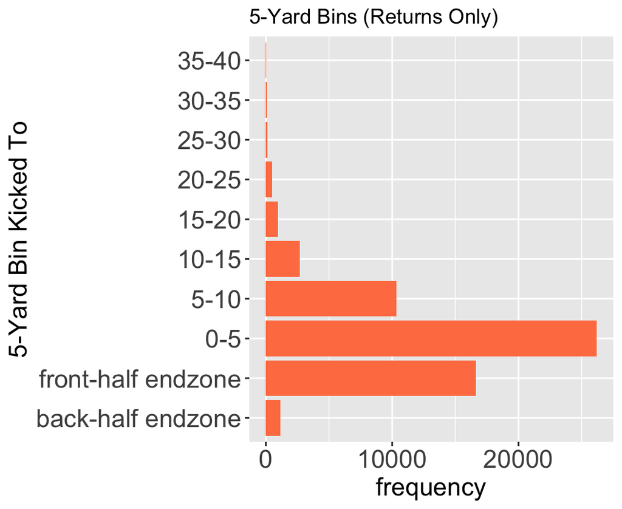

```r
ggplot(returns, aes(x = kickedto_5yardBin)) + geom_histogram(stat = "count",
    fill = "coral") + coord_flip() + xlab("5-Yard Bin Kicked To") + ylab("frequency") +
    theme(axis.text = element_text(size = 16), axis.title = element_text(size = 16)) +
    ggtitle("5-Yard Bins (Returns Only)")
```

### Scatter Plots

Let’s take a look at some scatter plots of our variables.

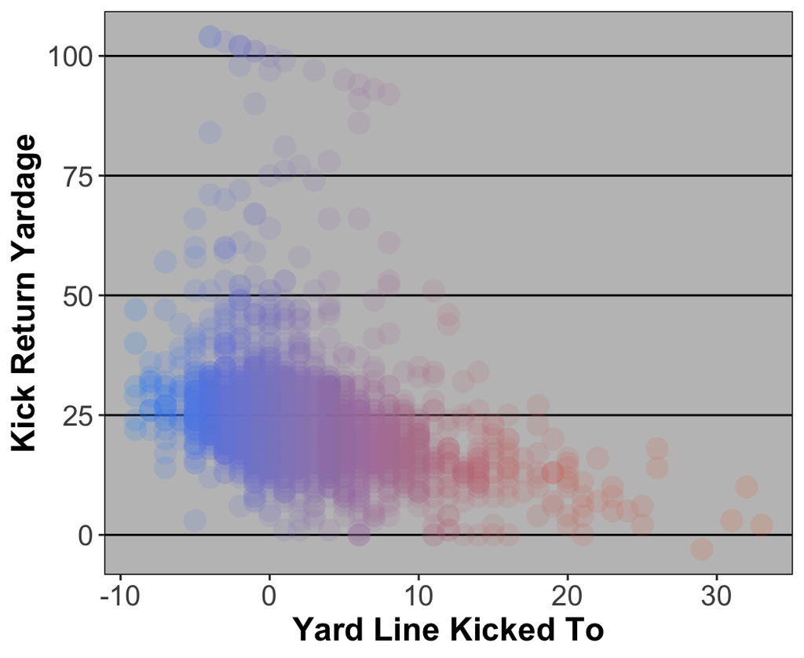

```r
ggplot(data = df, aes(x = kickedto_yardline, y = kickReturnYardage, color = kickedto_yardline,
    alpha = 1/density)) + geom_point(shape = 16, size = 5, show.legend = FALSE,
    alpha = 0.15) + theme_excel(base_size = ) + labs(x = "Yard Line Kicked To",
    y = "Kick Return Yardage") + scale_color_gradient(low = "#0091ff",
    high = "#f0650e") + scale_alpha(range = c(0.05, 0.25)) + theme(axis.text = element_text(size = 14),
    axis.title = element_text(size = 16, face = "bold"))
```

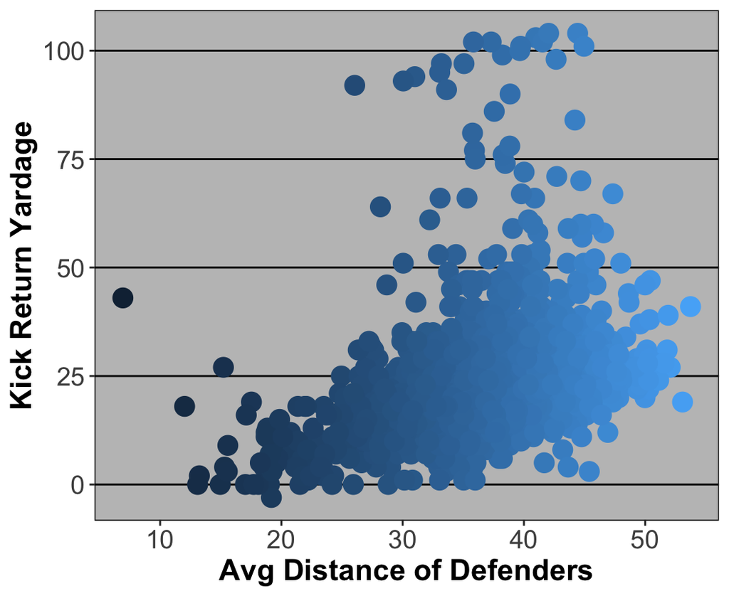

```r
ggplot(data = df, aes(x = KoTeamAvgDist, y = kickReturnYardage, color = KoTeamAvgDist)) +
    geom_point(shape = 16, size = 5, show.legend = FALSE) + theme_excel(base_size = 16) +
    labs(x = "Avg Distance of Defenders", y = "Kick Return Yardage") +
    theme(axis.text = element_text(size = 14), axis.title = element_text(size = 16,
        face = "bold"))
```

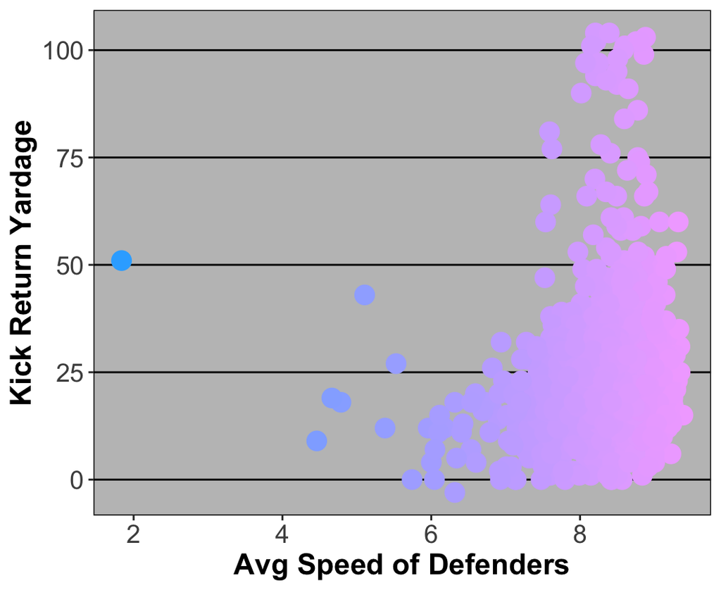

```r
ggplot(data = df, aes(x = KoTeamAvgSpeed, y = kickReturnYardage, color = KoTeamAvgSpeed)) +
    geom_point(shape = 16, size = 5, show.legend = FALSE) + theme_excel(base_size = 16) +
    labs(x = "Avg Speed of Defenders", y = "Kick Return Yardage") + scale_color_gradient(low = "#32aeff",
    high = "#f2aeff") + theme(axis.text = element_text(size = 14), axis.title = element_text(size = 16,
    face = "bold"))
```

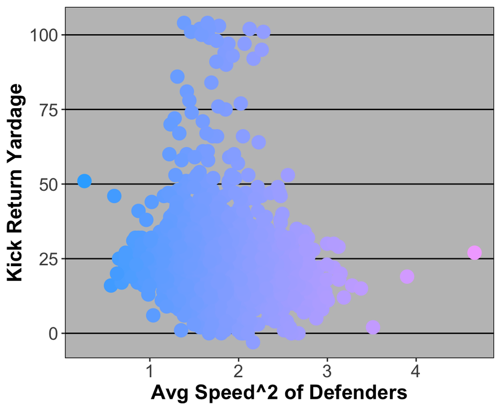

```r
ggplot(data = df, aes(x = KoTeamAvgA, y = kickReturnYardage, color = KoTeamAvgA)) +
    geom_point(shape = 16, size = 5, show.legend = FALSE) + theme_excel(base_size = 16) +
    labs(x = "Avg Speed^2 of Defenders", y = "Kick Return Yardage") + scale_color_gradient(low = "#32aeff",
    high = "#f2aeff") + theme(axis.text = element_text(size = 14), axis.title = element_text(size = 16,
    face = "bold"))
```

**Removing Outliers**

After seeing this I think I’m going to take out plays that were returned more than 50 yards because they are outliers and may be skewing our data.

```r
# Removing outliers

df_NoOutliers <- df %>%
    filter(yard_result < 50)
```

## Building a Linear Model

```r
mod1 <- lm(kickReturnYardage ~ kickedto_yardline + KoTeamAvgDist + KoTeamAvgA +
    Y_position + kickType + specialTeamsResult, data = df)

tab_model(mod1)
```

|  | kick Return Yardage |  |  |
| --- | --- | --- | --- |
| Predictors | Estimates | CI | p |
| (Intercept) | -3.44 | -10.53 – 3.65 | 0.341 |
| kickedto yardline | -0.27 | -0.40 – -0.14 | **<0.001** |
| KoTeamAvgDist | 0.50 | 0.36 – 0.63 | **<0.001** |
| KoTeamAvgA | 0.98 | -0.30 – 2.27 | 0.133 |
| Y position [left] | -1.66 | -2.78 – -0.54 | **0.004** |
| Y position [right] | -1.33 | -2.46 – -0.21 | **0.020** |
| kickType [F] | -0.33 | -2.36 – 1.71 | 0.752 |
| kickType [P] | -2.80 | -4.61 – -0.99 | **0.002** |
| specialTeamsResult [Return] | 9.01 | 5.93 – 12.09 | **<0.001** |
| Observations | 2648 |  |  |
| R<sup>2</sup> / R<sup>2</sup> adjusted | 0.156 / 0.154 |  |  |

**Generating Predictions**

```r
# Creating a split with 75% of the data in the training set
df_split <- initial_split(df, prop = 0.75)
df_train <- training(df_split)
df_test <- testing(df_split)

mod2 <- lm(kickReturnYardage ~ kickedto_yardline + KoTeamAvgDist + Y_position +
    kickType + specialTeamsResult, data = df)

# Generating in-sample (training) predictions
preds_test <- predict(mod2, newdata = df_test)

# Generating out-of-sample (testing) predictions
preds_train <- predict(mod2, newdata = df_train)

# Mean Squared Error
get_rmse <- function(true, predictions) {
    sqrt(mean((true - predictions)^2))
}

get_rmse(df_train$yard_result, preds_train)
```

```
## [1] 12.01806
```

```r
get_rmse(df_test$yard_result, preds_test)
```

```
## [1] 12.84061
```

```r
# Test Error > Training Error means model is overfit Test Error <
# Training Error means model is underfit We want test error to ~
# training
```

## Logistic Regression

```r
logit <- glm(YardResult_over25 ~ kickedto_yardline + hangTime + specialTeamsResult +
    KoTeamAvgDist + KoTeamAvgSpeed, family = binomial, data = df)

summary(logit)
```

```
##
## Call:
## glm(formula = YardResult_over25 ~ kickedto_yardline + hangTime +
##     specialTeamsResult + KoTeamAvgDist + KoTeamAvgSpeed, family = binomial,
##     data = df)
##
## Deviance Residuals:
##     Min       1Q   Median       3Q      Max
## -2.2691  -1.0424  -0.8238   1.2121   2.6227
##
## Coefficients:
##                          Estimate Std. Error z value
## (Intercept)              -3.51416    1.34253  -2.618
## kickedto_yardline         0.17254    0.01607  10.739
## hangTime                 -0.03257    0.19401  -0.168
## specialTeamsResultReturn  1.66074    0.45694   3.635
## KoTeamAvgDist             0.10409    0.01512   6.885
## KoTeamAvgSpeed           -0.28369    0.10260  -2.765
##                                      Pr(>|z|)
## (Intercept)                          0.008856 **
## kickedto_yardline        < 0.0000000000000002 ***
## hangTime                             0.866673
## specialTeamsResultReturn             0.000278 ***
## KoTeamAvgDist                0.00000000000577 ***
## KoTeamAvgSpeed                       0.005691 **
## ---
## Signif. codes:  0 '***' 0.001 '**' 0.01 '*' 0.05 '.' 0.1 ' ' 1
##
## (Dispersion parameter for binomial family taken to be 1)
##
##     Null deviance: 3489.4  on 2539  degrees of freedom
## Residual deviance: 3299.2  on 2534  degrees of freedom
##   (115 observations deleted due to missingness)
## AIC: 3311.2
##
## Number of Fisher Scoring iterations: 4
```

```r
exp(logit$coefficients)
```

```
##              (Intercept)        kickedto_yardline
##               0.02977291               1.18831836
##                 hangTime specialTeamsResultReturn
##               0.96795265               5.26320293
##            KoTeamAvgDist           KoTeamAvgSpeed
##               1.10969902               0.75300042
```

```r
preds_trainLogit <- predict(logit, newdata = df_train)

preds_testLogit <- predict(logit, newdata = df_test)

head(preds_testLogit)
```

```
##          1          2          3          4          5          6
##  1.9214100 -1.1234775 -0.5036481 -1.1479345 -0.7216348         NA
```

```r
head(preds_trainLogit)
```

```
##           1           2           3           4           5
## -0.48579288  0.08489535 -0.36867629 -0.43023333 -0.40863336
##           6
## -0.06525577
```

**Generating Results Data Frames**

```r
results_train <- data.frame(truth = df_train %>%
    select(YardResult_over25) %>%
    mutate(YardResult_over25 = as.numeric(YardResult_over25)), Class1 = preds_trainLogit,
    type = rep("train", length(preds_trainLogit)))

results_test <- data.frame(truth = df_test %>%
    select(YardResult_over25) %>%
    mutate(YardResult_over25 = as.numeric(YardResult_over25)), Class1 = preds_testLogit,
    type = rep("test", length(preds_testLogit)))

results <- bind_rows(results_train, results_test)

slice(results)
```

|  | truth.displayName.x | truth.gameId | truth.playId | truth.YardResult_over25 | Class1 | type |
| --- | --- | --- | --- | --- | --- | --- |
| 1...1 | Corey Clement | 2018120300 | 1276 | 1 | -0.48579288033 | train |
| 2...2 | Tremon Smith | 2018121300 | 2576 | 1 | 0.08489535387 | train |
| 3...3 | Rashaad Penny | 2018110408 | 1042 | 1 | -0.36867628502 | train |
| 4...4 | D'Ernest Johnson | 2019122903 | 1267 | 1 | -0.43023332917 | train |
| 5...5 | Corey Coleman | 2018112506 | 1953 | 2 | -0.40863335730 | train |
| 6...6 | Boston Scott | 2020122011 | 2166 | 1 | -0.06525576731 | train |
| 7...7 | Tony Pollard | 2020100403 | 3195 | 1 | -0.64890277386 | train |
| 8...8 | Trevor Davis | 2019092905 | 4460 | 1 | 0.83388882705 | train |
| 9...9 | Desmond King | 2019110310 | 36 | 1 | -1.11265373881 | train |
| 10...10 | Diontae Spencer | 2019111705 | 3779 | 2 | -0.65684511181 | train |

[output cut: 2645 more lines]

**Generating ROC Plots**

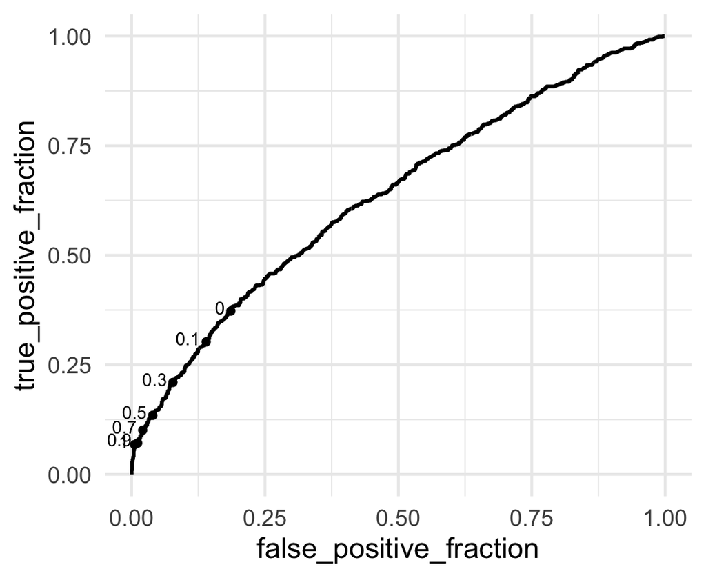

```r
p_train <- ggplot(results_train, aes(m = Class1, d = truth.YardResult_over25)) +
    geom_roc(labelsize = 3.5, cutoffs.at = c(0.99, 0.9, 0.7, 0.5, 0.3,
        0.1, 0)) + theme_minimal(base_size = 16)

p_test <- ggplot(results_test, aes(m = Class1, d = truth.YardResult_over25)) +
    geom_roc(labelsize = 3.5, cutoffs.at = c(0.99, 0.9, 0.7, 0.5, 0.3,
        0.1, 0)) + theme_minimal(base_size = 16)

print(p_train)
```

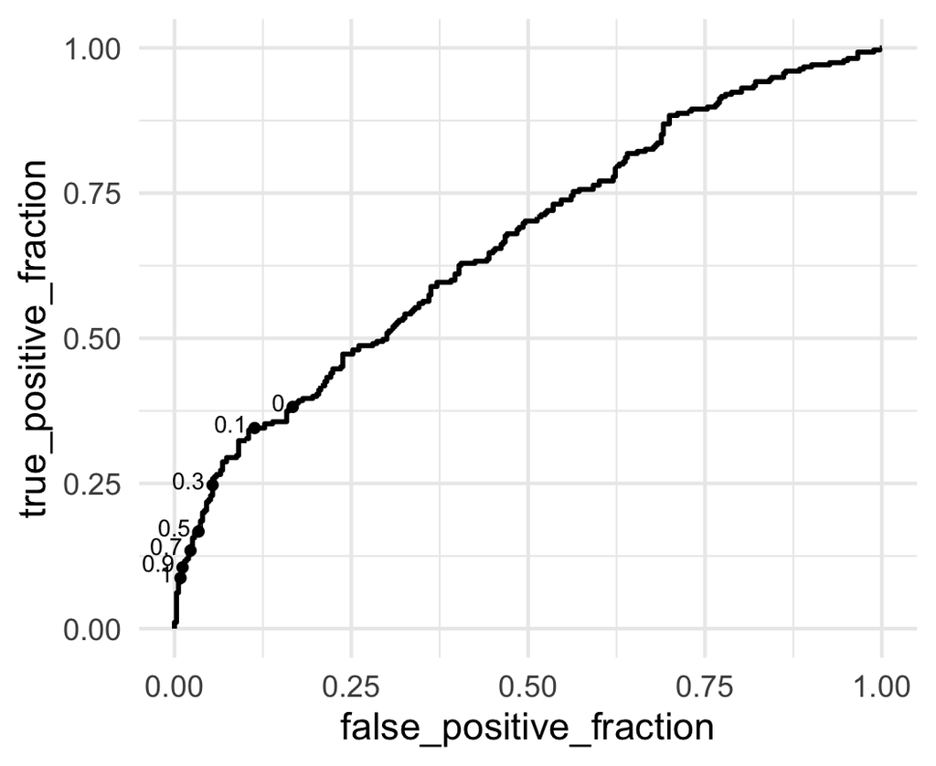

```r
print(p_test)
```

**Calculating AUC**

Calculating the AUC for the test and training sets using the functions calc_auc

```r
calc_auc(p_train)
```

| PANEL | group | AUC |
| --- | --- | --- |
| 1 | -1 | 0.6350452 |

```r
calc_auc(p_test)
```

| PANEL | group | AUC |
| --- | --- | --- |
| 1 | -1 | 0.6637651 |

## Elastic Net Model

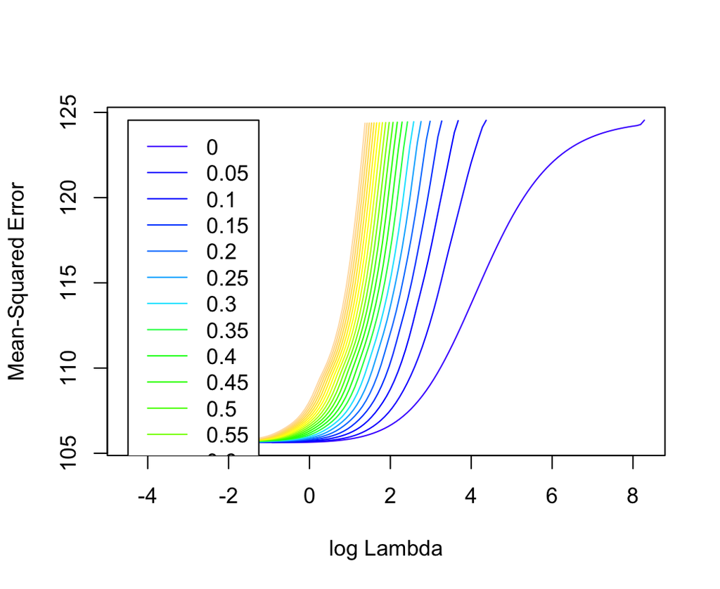

```r
enet_mod <- cva.glmnet(kickReturnYardage ~ kickedto_yardline + KoTeamAvgDist +
    KoTeamAvgA + Y_position + kickType + specialTeamsResult, data = df,
    alpha = seq(0, 1, by = 0.05))
plot(enet_mod)
```

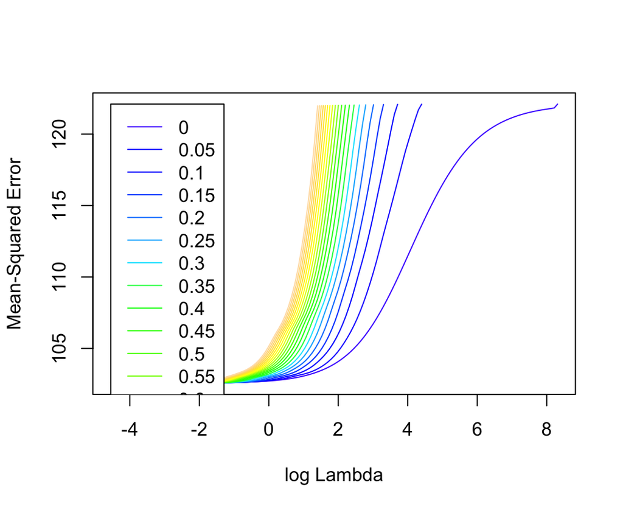

```r
enet_mod <- cva.glmnet(kickReturnYardage ~ kickedto_yardline + KoTeamAvgDist +
    KoTeamAvgA + Y_position + kickType + specialTeamsResult, data = df_train,
    alpha = seq(0, 1, by = 0.05))

plot(enet_mod)
```

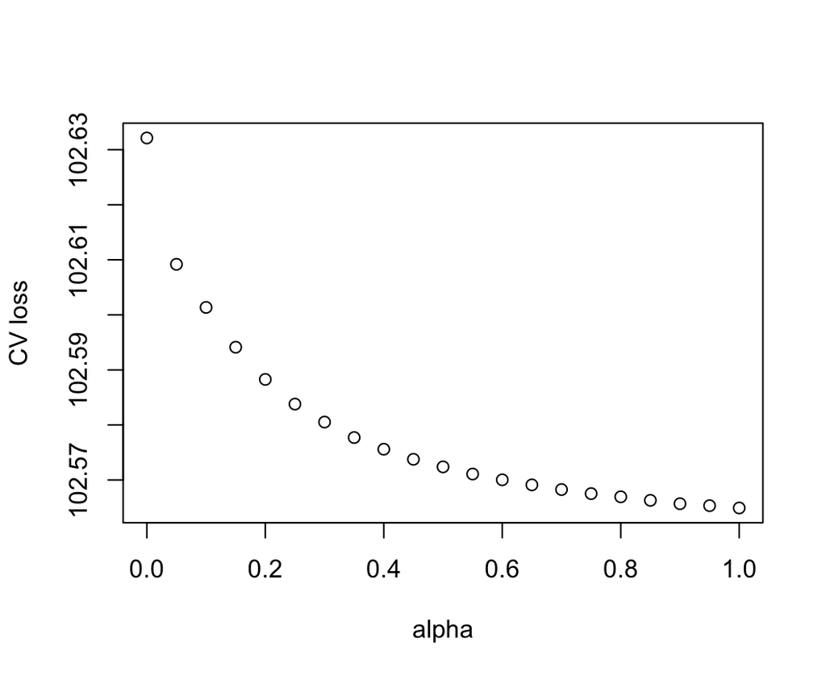

```r
# now enet_mod holds a list with all of the sub models, each with
# alpha = whatever sequence the model was estimated with
minlossplot(enet_mod, cv.type = "min")
```

```r
# Use this function to find the best alpha
get_alpha <- function(fit) {
    alpha <- fit$alpha
    error <- sapply(fit$modlist, function(mod) {
        min(mod$cvm)
    })
    alpha[which.min(error)]
}
```

```r
# Get all parameters.
get_model_params <- function(fit) {
    alpha <- fit$alpha
    lambdaMin <- sapply(fit$modlist, `[[`, "lambda.min")
    lambdaSE <- sapply(fit$modlist, `[[`, "lambda.1se")
    error <- sapply(fit$modlist, function(mod) {
        min(mod$cvm)
    })
    best <- which.min(error)
    data.frame(alpha = alpha[best], lambdaMin = lambdaMin[best], lambdaSE = lambdaSE[best],
        eror = error[best])
}
```

```r
# extract the best alpha value and model parameters
best_alpha <- get_alpha(enet_mod)
print(best_alpha)
```

```
## [1] 1
```

```r
get_model_params(enet_mod)
```

| alpha | lambdaMin | lambdaSE | eror |
| --- | --- | --- | --- |
| 1 | 0.07457762 | 3.081556 | 102.5649 |

```r
# extract the best model object
best_mod <- enet_mod$modlist[[which(enet_mod$alpha == best_alpha)]]
print(best_mod)
```

```
##
## Call:  glmnet::cv.glmnet(x = x, y = y, weights = ..1, offset = ..2,      nfolds = nfolds, foldid = foldid, alpha = a)
##
## Measure: Mean-Squared Error
##
##     Lambda Index Measure    SE Nonzero
## min 0.0746    44   102.6 13.18       7
## 1se 3.0816     4   115.0 12.60       1
```

```r
summary(enet_mod)
```

```
##                 Length Class  Mode
## alpha           21     -none- numeric
## nfolds           1     -none- numeric
## modlist         21     -none- list
## call             4     -none- call
## terms            2     -none- call
## xlev             6     -none- list
## sparse           1     -none- logical
## use.model.frame  1     -none- logical
## na.action        1     -none- character
```

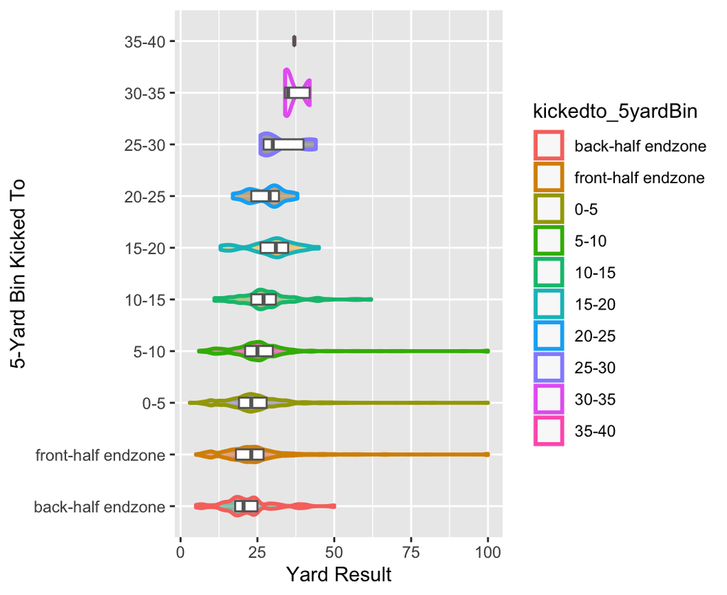

```r
# Also heres the code for the plot I put in the slides
g <- ggplot(returns, aes(x = kickedto_5yardBin, y = yard_result, color = kickedto_5yardBin)) +
    labs(x = "5-Yard Bin Kicked To", y = "Yard Result")

# Since Boxplots are boring, I made a violin plot instead
g + geom_violin(aes(fill = kickedto_5yardBin), size = 1, alpha = 0.5) +
    geom_boxplot(outlier.alpha = 0, coef = 0, color = "gray40", width = 0.2) +
    scale_fill_brewer(palette = "Dark2", guide = "none") + coord_flip()
```

## Random Forest

```r
NFL_rf_fit2 <- randomForest(YardResult_over25 ~ kickedto_yardline + hangTime +
    kickoffReturnFormation + Y_position + KoTeamAvgDist + KoTeamAvgSpeed,
    data = df, type = classification, mtry = 4, na.action = na.roughfix,
    ntree = 1500, localImp = TRUE)


print(NFL_rf_fit2)
```

```
##
## Call:
##  randomForest(formula = YardResult_over25 ~ kickedto_yardline +      hangTime + kickoffReturnFormation + Y_position + KoTeamAvgDist +      KoTeamAvgSpeed, data = df, type = classification, mtry = 4,      ntree = 1500, localImp = TRUE, na.action = na.roughfix)
##                Type of random forest: classification
##                      Number of trees: 1500
## No. of variables tried at each split: 4
##
##         OOB estimate of  error rate: 40.98%
## Confusion matrix:
##      0   1 class.error
## 0 1000 451   0.3108201
## 1  637 567   0.5290698
```

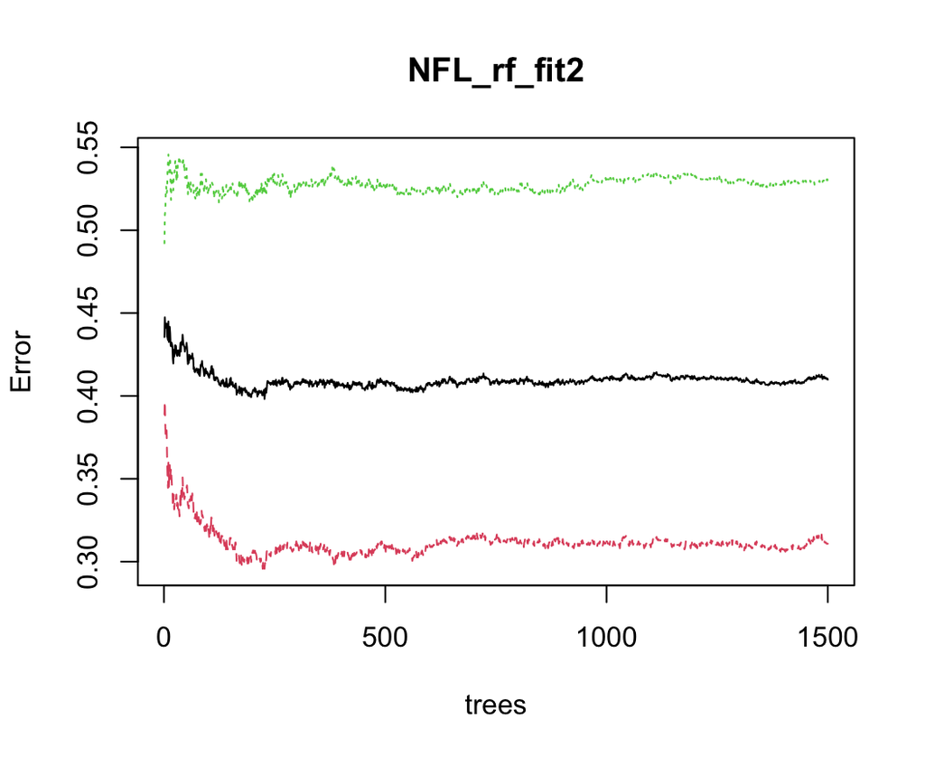

```r
plot(NFL_rf_fit2)
```

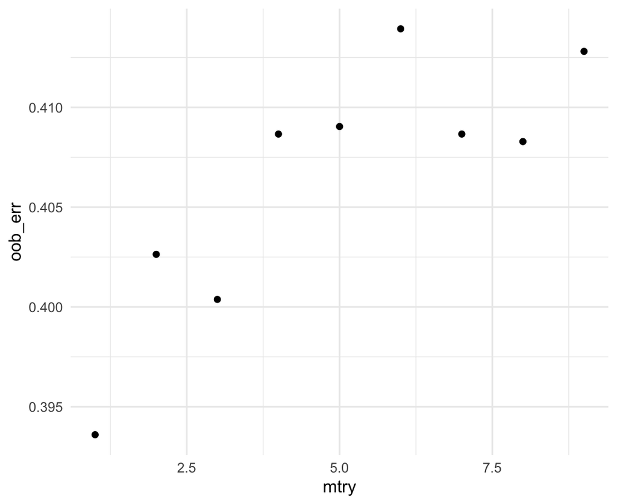

```r
rf_mods <- list()
oob_err <- NULL
test_err <- NULL
for (mtry in 1:9) {
    NFL_rf_fit2 <- randomForest(YardResult_over25 ~ kickedto_yardline +
        hangTime + kickoffReturnFormation + Y_position + KoTeamAvgDist +
        KoTeamAvgSpeed, data = df, mtry = mtry, na.action = na.roughfix,
        ntree = 500)
    oob_err[mtry] <- NFL_rf_fit2$err.rate[500]

    cat(mtry, " ")
}
## 1  2  3  4  5  6  7  8  9
## 1 2 3 4 5 6 7 8 9

results_DF <- data.frame(mtry = 1:9, oob_err)
ggplot(results_DF, aes(x = mtry, y = oob_err)) + geom_point() + theme_minimal() +
    xlim(1, 9)
```

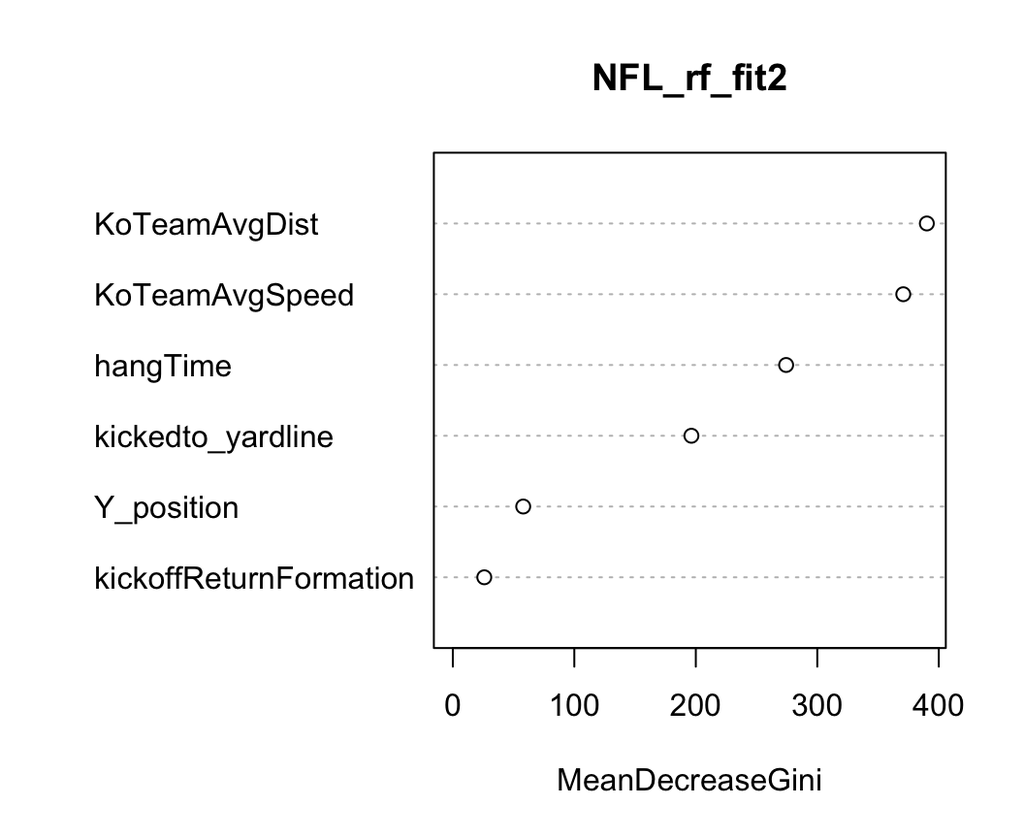

```r
varImpPlot(NFL_rf_fit2)
```

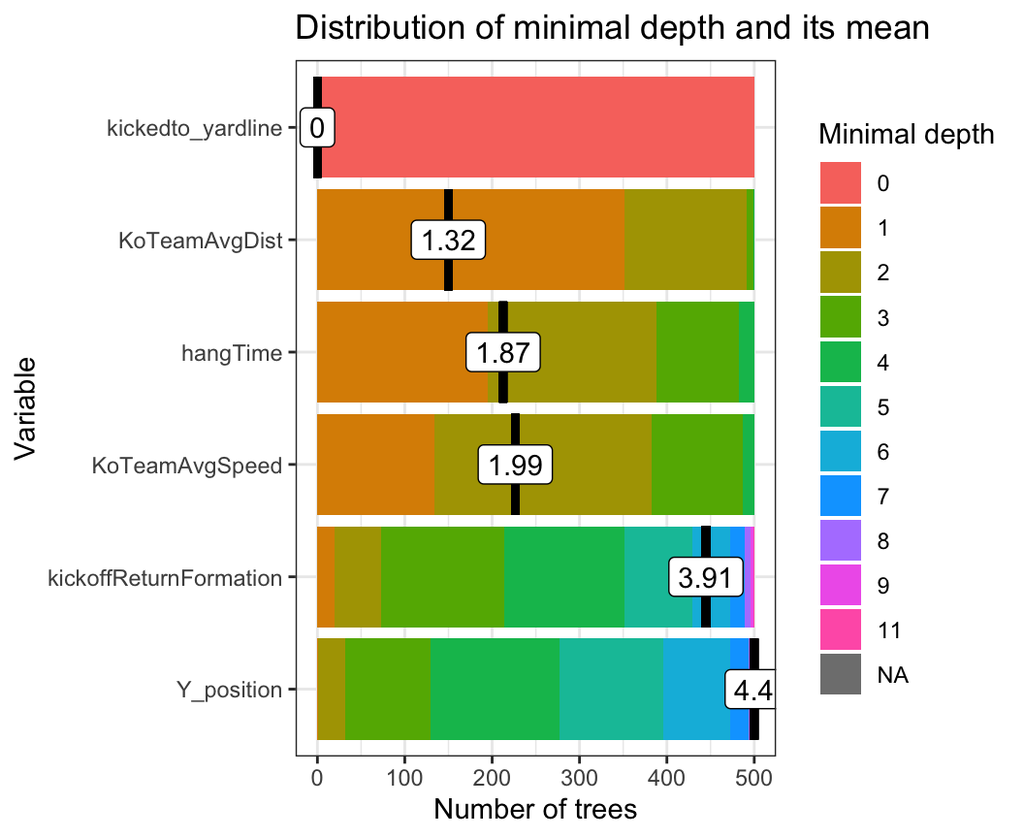

```r
plot_min_depth_distribution(NFL_rf_fit2)
```

```
## [1] "Warning: your forest does not contain information on local importance so 'accuracy_decrease' measure cannot be extracted. To add it regrow the forest with the option localImp = TRUE and run this function again."
```

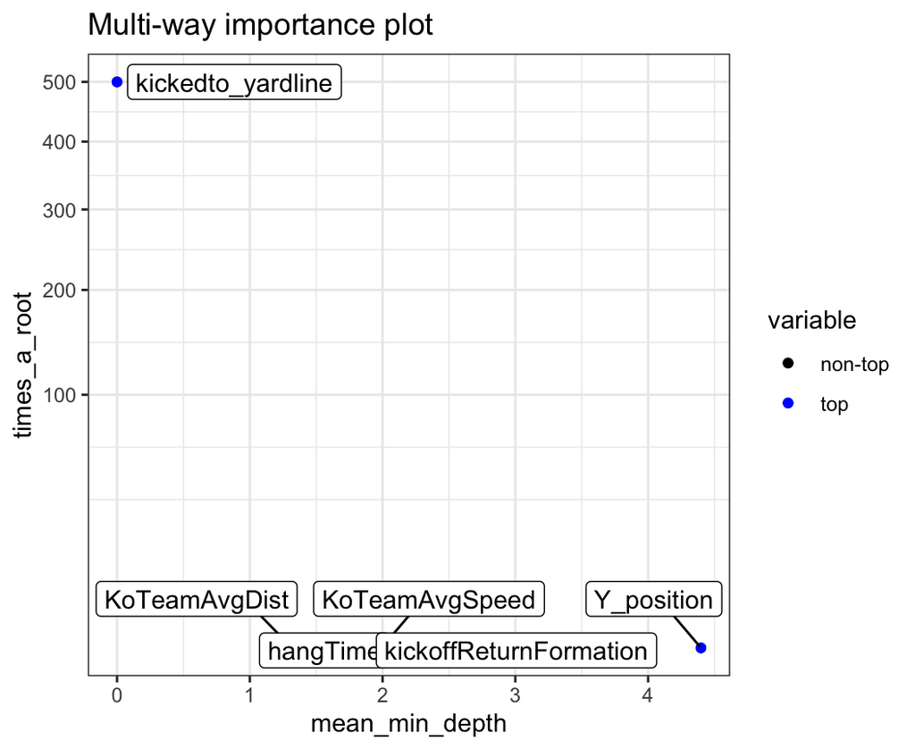

```r
plot_multi_way_importance(NFL_rf_fit2)
```

Next Next Steps:

Blockers and Shapley values

Nueral Networks using s, a, dir, x, and y? - Last years expected rushing yards model used just those variables for all 22 players on the field